# Data Vis example: Contraception data

10:55 11 February 2019

```r
library(mlmRev) ## for contraception data
library(ggplot2)
```

Adjust some graphical parameters:

```r
theme_set(theme_bw()+
          theme(panel.spacing=grid::unit(0,"lines")))
```

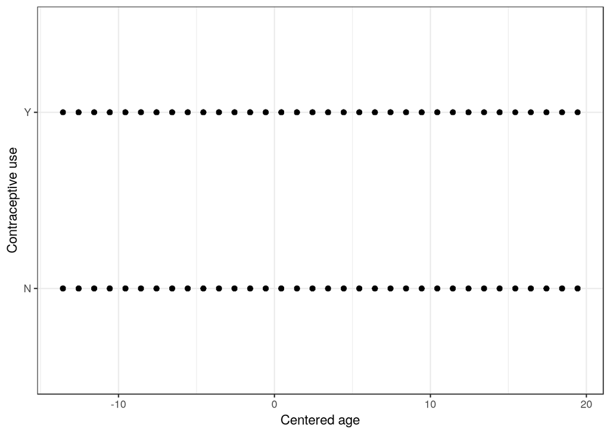

```r
g1 <- (ggplot(Contraception,aes(x=age,y=use))+
       labs(x="Centered age",y="Contraceptive use")
)
print(g1+geom_point())
```

Not very useful!

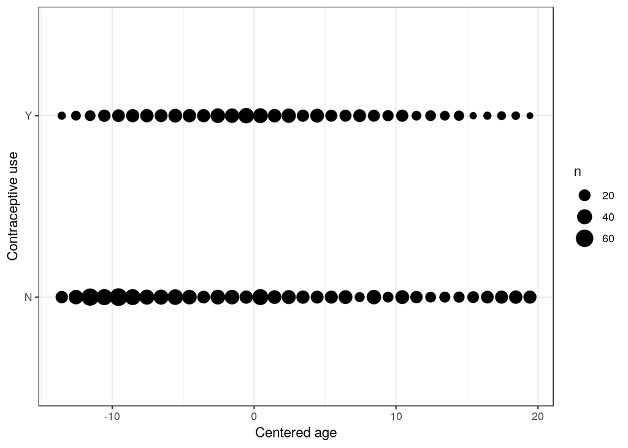

```r
print(g1+stat_sum())
```

Use transparency – not a mapping (which would be inside an `aes()` function) but a hard-coded value:

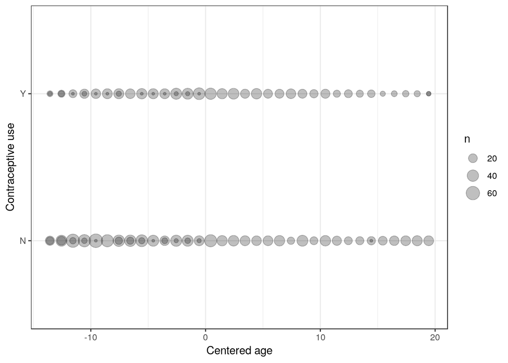

```r
print(g1+stat_sum(alpha=0.25))
```

Distinguish by number of live children:

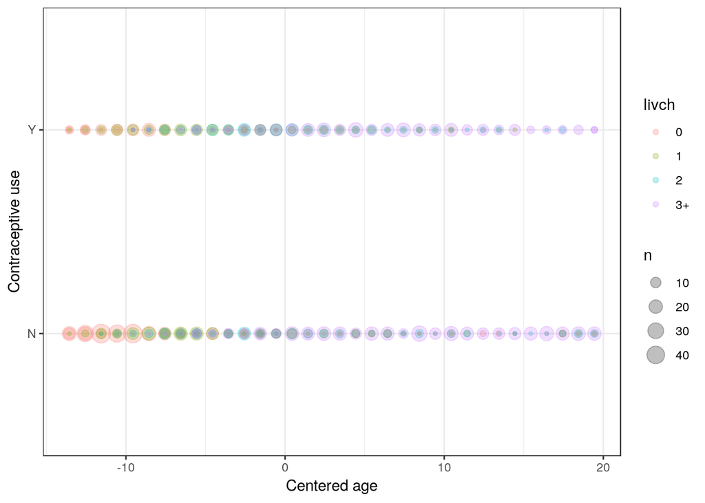

```r
g2 <- (ggplot(Contraception,aes(x=age,y=use,colour=livch))
    + labs(x="Centered age",y="Contraceptive use"))
g3 <- g2 + stat_sum(alpha=0.25)
print(g3)
```

Add smooth lines:

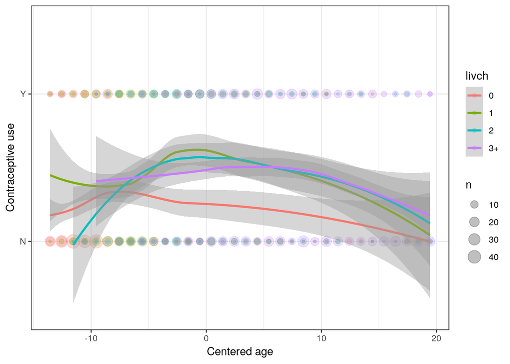

```r
g4 <- (g3
    + geom_smooth(aes(y=as.numeric(use)))
)
print(g4)
```

Adjust the axis limits.

[figure not shown]

```r
g5 <- (g4
    + coord_cartesian(ylim=c(0.9,2.1))
)
print(g5)
```

Technical details:

- we need to know that the numeric values on the $y$ axis actually correspond to the underlying **numeric** factor codes (N=1,Y=2);
- we use `coord_cartesian(ylim=...)` rather than just saying `+ylim(0.9,2.1)`, which will erase the confidence-interval ribbons that go below the lower limits of the graph (although `oob=scales::squish` is useful here)

Facet by urban/rural: the syntax is `rows~columns`, and `.` here means “nothing”, or “only a single row” (cf. `facet_wrap`)

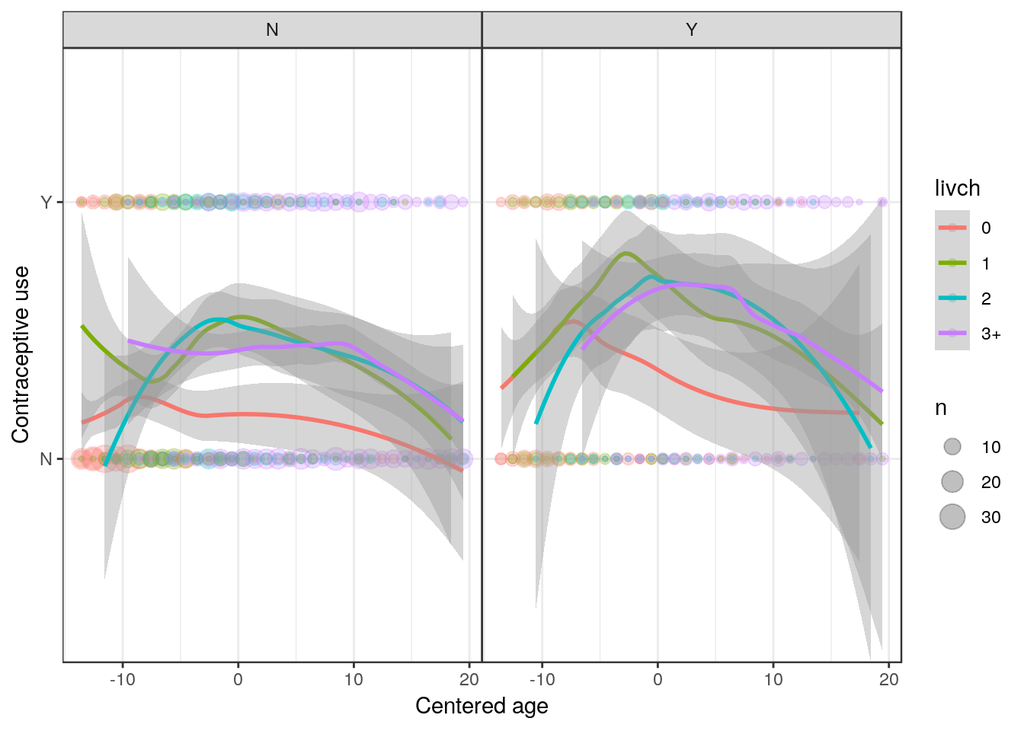

```r
g4+facet_grid(.~urban)
```

Separate urban/rural by line type instead (and turn off confidence-interval ribbons):

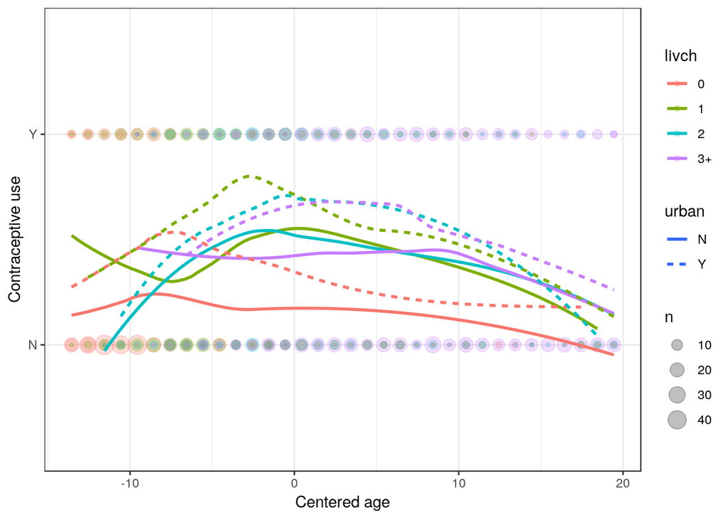

```r
g3 + geom_smooth(aes(y=as.numeric(use),lty=urban),se=FALSE)
```

- Technical detail: we need `as.numeric(use)` because `use` is a factor.

Or make the confidence-interval ribbons light (`alpha=0.1`) instead of turning them off completely:

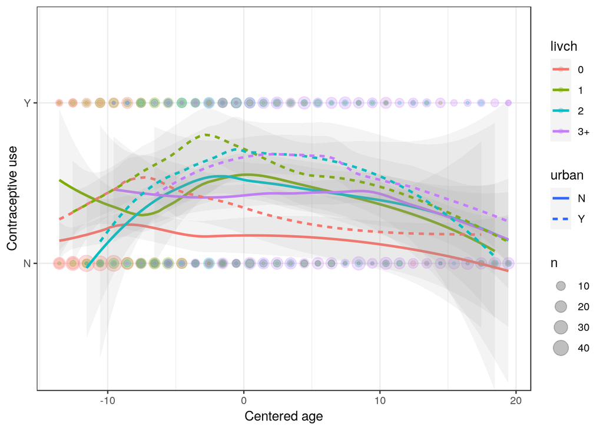

```r
print(g3 + geom_smooth(aes(y=as.numeric(use),
                           lty=urban),alpha=0.1))
```

Advanced topic: smooth by fitting a polynomial logistic regression.

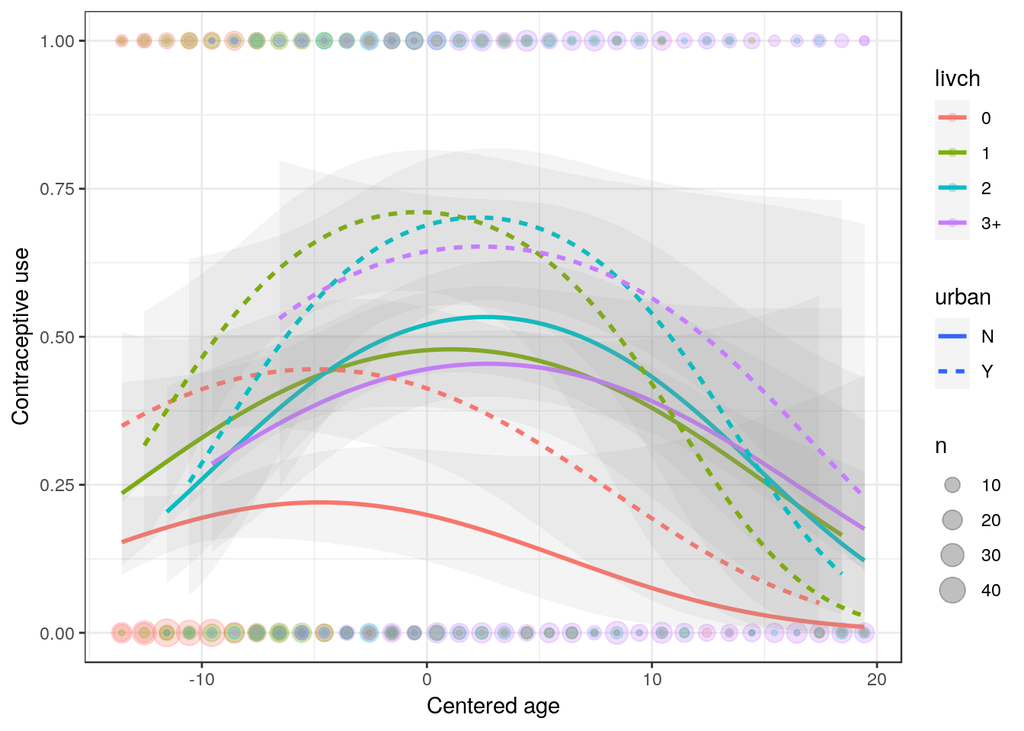

```r
g6 <- ggplot(Contraception,aes(x=age,
                                y=as.numeric(use)-1,
                                colour=livch))+
    stat_sum(alpha=0.25)+labs(x="Centered age",y="Contraceptive use")
print(g6 + geom_smooth(aes(lty=urban),method="glm",
                 method.args=list(family="binomial"),
                 formula=y~poly(x,2),alpha=0.1))
```

Technical details:

- have to convert $y$ from (1,2) to (0,1) so that logistic regression makes sense

A more common use would be to use `method="lm"` to get linear regression lines for each group.

Two-way faceting:

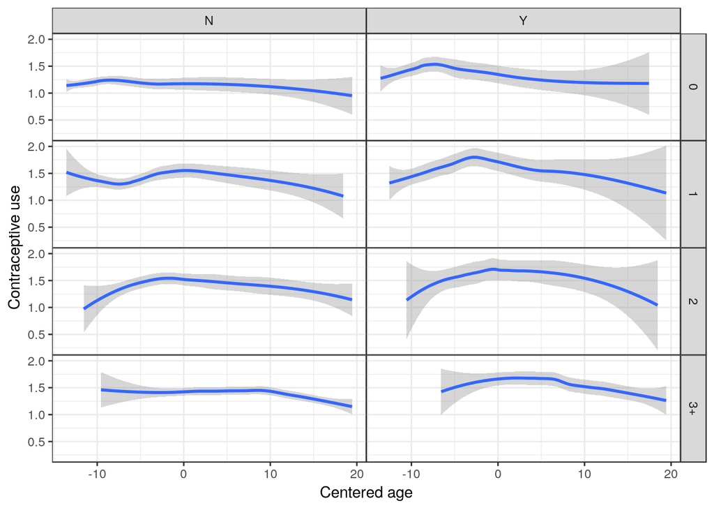

```r
print(g1 +
      facet_grid(livch~urban)+geom_smooth(aes(y=as.numeric(use)))
      )
```

This is nice, although a plot without data is always a little scary.

Use a generalized additive model (takes some more tweaking, see `k` parameter!)

[figure not shown]

```r
g5 + geom_smooth(aes(lty=urban),method="gam",
                 method.args=list(family="binomial"),
                 formula=y~s(x,k=20),
                 alpha=0.1)
```